# CA1

## 2109039

## EL/EP0302/FT/03

### Title of data analysis:

## Which flat type offers the most favorable investment opportunity for rental purposes in a specific town within a price range of 500000SGD?

importing neccesary packages.

```python
import numpy as np
import matplotlib.pyplot as plt
```

reading csv files

```python
# https://data.gov.sg/dataset/resale-flat-prices
data_resale_flat_prices = np.genfromtxt('./Datasets/resale-flat-prices-based-on-registration-date-from-jan-2017-onwards.csv', delimiter=',', dtype=[
                                        'datetime64[M]', 'U20', 'U20', 'U5', 'U45', 'U30', int, 'U30', 'datetime64[Y]', 'U30', int], names=True)

# https://data.gov.sg/dataset/median-rent-by-town-and-flat-type
data_median_rent = np.genfromtxt('./Datasets/median-rent-by-town-and-flat-type.csv',
                                 delimiter=',', dtype=['U30', 'U30', 'U10', int], names=True)

# https://data.gov.sg/dataset/renting-out-of-flats
data_renting_flats = np.genfromtxt('./Datasets/renting-out-of-flats.csv',delimiter=',',dtype=['U30','U30','U15','U45','U15',int],names=True)

# https://data.gov.sg/dataset/school-directory-and-information?view_id=ba7c477d-a077-4303-96a1-ac1d4f25b190&resource_id=ede26d32-01af-4228-b1ed-f05c45a1d8ee
data_school_info = np.genfromtxt('./Datasets/general-information-of-schools.csv', delimiter=',',dtype=['U45','U45','U45','U15','U30','U30','U15','U30','U30','U30','U30','U30','U30','U30','U30','U30','U30','U5','U5','U5'] ,names=True)
```

List of URLs of dataset

- https://data.gov.sg/dataset/resale-flat-prices
- https://data.gov.sg/dataset/median-rent-by-town-and-flat-type
- https://data.gov.sg/dataset/renting-out-of-flats
- https://data.gov.sg/dataset/school-directory-and-information

### Resale flat prices based on registration date dataset.

```python
print("**This is the resale flat prices dataset**")
print(f'There are {len(data_resale_flat_prices)} rows of data in this dataset.')
print(f'There are {len(np.unique(data_resale_flat_prices["flat_type"]))} flat types in this dataset.')
print(f'There are {len(np.unique(data_resale_flat_prices["town"]))} towns in this dataset.')
print()

mg = data_resale_flat_prices['flat_type']=='MULTI-GENERATION'
print(f'The average price of a Multi-Generation flat is {round(np.mean(data_resale_flat_prices[mg]["resale_price"]),2)} SGD.')
print()

executive = data_resale_flat_prices['flat_type']=='EXECUTIVE'
print(f'The average price of an Executive flat is {round(np.mean(data_resale_flat_prices[executive]["resale_price"]),2)} SGD.')
print()

room_5 = data_resale_flat_prices['flat_type']=='5 ROOM'
print(f'The average price of a 5 Room flat is {round(np.mean(data_resale_flat_prices[room_5]["resale_price"]),2)} SGD.')
print()

room_4 = data_resale_flat_prices['flat_type']=='4 ROOM'
print(f'The average price of a 4 Room flat is {round(np.mean(data_resale_flat_prices[room_4]["resale_price"]),2)} SGD.')
print()

room_3 = data_resale_flat_prices['flat_type']=='3 ROOM'
print(f'The average price of a 3 Room flat is {round(np.mean(data_resale_flat_prices[room_3]["resale_price"]),2)} SGD.')
print()

room_2 = data_resale_flat_prices['flat_type']=='2 ROOM'
print(f'The average price of a 2 Room flat is {round(np.mean(data_resale_flat_prices[room_2]["resale_price"]),2)} SGD.')
print()

room_1 = data_resale_flat_prices['flat_type']=='1 ROOM'
print(f'The average price of a 1 Room flat is {round(np.mean(data_resale_flat_prices[room_1]["resale_price"]),2)} SGD.')
```

```
**This is the resale flat prices dataset**
There are 153114 rows of data in this dataset.
There are 7 flat types in this dataset.
There are 26 towns in this dataset.

The average price of a Multi-Generation flat is 821707.5 SGD.

The average price of an Executive flat is 676939.81 SGD.

The average price of a 5 Room flat is 576223.55 SGD.

The average price of a 4 Room flat is 478926.5 SGD.

The average price of a 3 Room flat is 337472.0 SGD.

The average price of a 2 Room flat is 259553.24 SGD.

The average price of a 1 Room flat is 196904.2 SGD.
```

### Nature Of The Dataset:

The CSV file "resale-flat-prices-based-on-registration-date-from-jan-2017-onwards" contains data on resale flat transactions in Singapore from January 2017 to the present. The data includes the following columns:

- Month: The month in which the resale transaction took place.
- Town: The town in which the resale flat is located.
- Flat type: The type of resale flat, such as 3-room, 4-room, 5-room etc.
- Block: The block number of the resale flat.
- Street name: The street name of the resale flat.
- Storey range: The storey range of the resale flat, such as 1-10, 11-20, 21-30 etc.
- Floor area (sqm): The floor area of the resale flat in square meters.
- Flat model: The model of the resale flat.
- Lease commence date: The date on which the lease on the resale flat commenced.
- Remaining lease: The number of years, months, and days of lease remaining on the resale flat.
- Resale price: The price at which the resale flat was sold.

- The data does not include information on the age of the resale flat. This information would be useful for understanding the relationship between the age of a flat and its resale price.
- The data does not include information on the number of bedrooms and bathrooms in the resale flat. This information would also be useful for understanding the relationship between the number of bedrooms and bathrooms in a flat and its resale price.
- The data does not include information on the amenities and facilities that are located near the resale flat. This information would be useful for understanding the relationship between the amenities and facilities near a flat and its resale price.

I analyzed the dataset using the following steps:

1. I imported the data into a Python Numpy Array.
2. I performed a statistical analysis of the data, including calculating the mean, of the resale prices by town, flat type, and other factors.
3. I created visualizations of the data, such as line chart, bar graph, pie chart and scatterplots.
4. I interpreted the results of the analysis to identify trends and patterns in the data.

### Median rent by town and flat type dataset.

```python
print("**This is the median rent by town and flat type dataset**")
print(f'There are {len(data_resale_flat_prices)} rows of data in this dataset.')
print(f'There are {len(np.unique(data_median_rent["town"]))} towns in this dataset.')
print(f'There are {len(np.unique(data_median_rent["flat_type"]))} flat types in this dataset.')
print()

print(f'The average median rental price of a Executive flat is {round(np.mean(data_median_rent[data_median_rent["flat_type"] == "EXEC"]["median_rent"]),2)} SGD.')
print()

print(f'The average median rental price of a 5 Room flat is {round(np.mean(data_median_rent[data_median_rent["flat_type"] == "5-RM"]["median_rent"]),2)} SGD.')
print()

print(f'The average median rental price of a 4 Room flat is {round(np.mean(data_median_rent[data_median_rent["flat_type"] == "4-RM"]["median_rent"]),2)} SGD.')
print()

print(f'The average median rental price of a 3 Room flat is {round(np.mean(data_median_rent[data_median_rent["flat_type"] == "3-RM"]["median_rent"]),2)} SGD.')
print()

print(f'The average median rental price of a 2 Room flat is {round(np.mean(data_median_rent[data_median_rent["flat_type"] == "2-RM"]["median_rent"]),2)} SGD.')
print()

print("There is no data available for the average rental price of a 1 room flat.")
```

```
**This is the median rent by town and flat type dataset**
There are 153114 rows of data in this dataset.
There are 53 towns in this dataset.
There are 6 flat types in this dataset.

The average median rental price of a Executive flat is 825.58 SGD.

The average median rental price of a 5 Room flat is 1786.29 SGD.

The average median rental price of a 4 Room flat is 1855.22 SGD.

The average median rental price of a 3 Room flat is 1272.27 SGD.

The average median rental price of a 2 Room flat is 46.34 SGD.

There is no data available for the average rental price of a 1 room flat.
```

### Nature Of The Dataset:

The CSV file "median-rent-by-town-and-flat-type" contains data on the median rent by town and flat type over various quarters. The data includes the following columns:

- Quarter: The quarter in which the rent was recorded.
- Town: The town in which the rent was recorded.
- Flat type: The type of flat, such as HDB or condominium.
- Median rent: The median rent for the quarter, town, and flat type.

- There are a few rows where the median rent is missing (i.e. "na", "-"). There is no data in the entire dataset which shows the median rent for 1 room flats.
- From the start of 2016-Q4 the town names have extra white space beside them hence making this dataset really hard to work with
- The median rent for some quarters is higher than the median rent for previous quarters. This may be due to a number of factors, such as an increase in demand for housing or an increase in the cost of construction.

I analyzed the dataset using the following steps:

1. I imported the data into a Python Numpy Array.
2. I performed a statistical analysis of the data, including calculating the mean, of the resale prices by town, flat type, and other factors.
3. I created visualizations of the data, such as line chart, bar graph and histogram.
4. I interpreted the results of the analysis to identify trends and patterns in the data.

Do note that this dataset(median-rent-by-town-and-flat-type.csv) has missing values and has not been cleaned. Because of this, some information about the median rent might be inaccurate.

### Renting out of flats dataset.

```python
print("**This is the renting out of flats dataset**")
print(f'There are {len(data_renting_flats)} rows of data in this dataset.')
print(f'There are {len(np.unique(data_renting_flats["town"]))} towns in this dataset.')
print(f'There are {len(np.unique(data_renting_flats["flat_type"]))} flat types in this dataset.')
print()

print(f'The average rental price of a Executive flat is {round(np.mean(data_renting_flats[data_renting_flats["flat_type"] == "EXECUTIVE"]["monthly_rent"]),2)} SGD.')
print()

print(f'The average rental price of a 5 Room flat is {round(np.mean(data_renting_flats[data_renting_flats["flat_type"] == "5-ROOM"]["monthly_rent"]),2)} SGD.')
print()

print(f'The average rental price of a 4 Room flat is {round(np.mean(data_renting_flats[data_renting_flats["flat_type"] == "4-ROOM"]["monthly_rent"]),2)} SGD.')
print()

print(f'The average rental price of a 3 Room flat is {round(np.mean(data_renting_flats[data_renting_flats["flat_type"] == "3-ROOM"]["monthly_rent"]),2)} SGD.')
print()

print(f'The average rental price of a 2 Room flat is {round(np.mean(data_renting_flats[data_renting_flats["flat_type"] == "2-ROOM"]["monthly_rent"]),2)} SGD.')
print()

print(f'The average rental price of a 1 Room flat is {round(np.mean(data_renting_flats[data_renting_flats["flat_type"] == "1-ROOM"]["monthly_rent"]),2)} SGD.')
print()
```

```
**This is the renting out of flats dataset**
There are 85787 rows of data in this dataset.
There are 26 towns in this dataset.
There are 6 flat types in this dataset.

The average rental price of a Executive flat is 2684.35 SGD.

The average rental price of a 5 Room flat is 2618.89 SGD.

The average rental price of a 4 Room flat is 2498.21 SGD.

The average rental price of a 3 Room flat is 2121.94 SGD.

The average rental price of a 2 Room flat is 1700.98 SGD.

The average rental price of a 1 Room flat is 1383.33 SGD.
```

### Nature Of The Dataset:

The CSV file "renting-out-of-flats" contains data on the monthly rental prices of flats in Singapore. The data includes the following columns:

- Rent Approval Date: The date on which the rental approval was granted.
- Town: The town in which the flat is located.
- Block: The block number of the flat.
- Street Name: The street name of the flat.
- Flat Type: The type of flat, such as HDB, condominium, or apartment.
- Monthly Rent: The monthly rent of the flat.

The dataset contains a total of 85787 rows of data. The data is relatively clean and well-formatted.

I analyzed the dataset using the following steps:

1. I imported the data into a Python Numpy Array.
2. I performed a statistical analysis of the data, including calculating the mean, of the resale prices by town, flat type, and other factors.
3. I created visualizations of the data, such as line chart and bar graphs.
4. I interpreted the results of the analysis to identify trends and patterns in the data.

### General Information of Schools Dataset.

```python
print("**This is the general information of schools dataset**")
print(f'There are {len(data_school_info)} rows of data in this dataset.')
print(f'There are {len(np.unique(data_school_info["school_name"]))} schools in this dataset.')
print(f'There are {len(np.unique(data_school_info["dgp_code"]))} towns in this dataset.')
print()
```

```
**This is the general information of schools dataset**
There are 346 rows of data in this dataset.
There are 346 schools in this dataset.
There are 27 towns in this dataset.
```

### Nature Of The Dataset:

The CSV file "general-information-of-schools" contains data on general information of schools in Singapore. The data includes the following columns:

- School Name: The name of the school
- URL Address: The URL address of the school's website
- Address: The physical address of the school
- Postal Code: The postal code of the school
- Telephone Number: The telephone number of the school
- Fax Number: The fax number of the school
- Email Address: The email address of the school
- DGP Code: The DGP code of the school
- Zone Code: The zone code of the school
- Type Code: The type code of the school
- Nature Code: The nature code of the school
- Session Code: The session code of the school
- Main Level Code: The main level code of the school
- SAP Ind: Indicates whether the school is a SAP school
- Autonomous Ind: Indicates whether the school is an autonomous school
- Gifted Ind: Indicates whether the school is a gifted school
- IP Ind: Indicates whether the school is an IP school
- Mother Tongue 1 Code: The mother tongue language code of the first language taught at the school
- Mother Tongue 2 Code: The mother tongue language code of the second language taught at the school
- Mother Tongue 3 Code: The mother tongue language code of the third language taught at the school

The dataset contains a total of 346 rows of data. The data is relatively clean and well-formatted. However, there are a few peculiarities that should be noted.

- Some of the school names contain special characters, such as spaces and hyphens.

I analyzed the dataset using the following steps:

1. I imported the data into a Python Numpy DataFrame.
2. I performed a statistical analysis of the data, including calculating the mean, of the resale prices by town, flat type, and other factors.
3. I created visualizations of the data, such as bar graph, as well as a stacked bar graph.
4. I interpreted the results of the analysis to identify trends and patterns in the data.

## Resale flat prices based on registration date from Jan 2017 onwards dataset

### What is the difference in the prices of flat types?

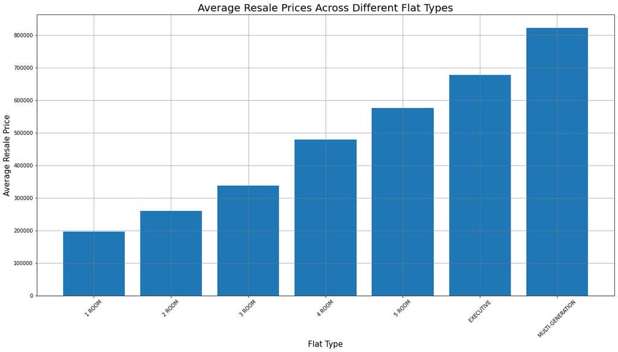

```python
# getting the different flat types
flat_types = np.unique(data_resale_flat_prices['flat_type'])

# getting the average resale prices for each flat type
# creating an numpy array with the length of flat types
resale_prices = np.zeros(len(flat_types))
# finding average resale price of each flat type and storing them into resale_prices array
for i in range(len(flat_types)):
    resale_prices[i] = np.mean(data_resale_flat_prices['resale_price'][data_resale_flat_prices['flat_type'] == flat_types[i]])

# Plotting the graph
plt.figure(figsize=(20, 10))
plt.bar(flat_types, resale_prices)
plt.xlabel('Flat Type',fontsize=15)
plt.ylabel('Average Resale Price',fontsize=15)
plt.title('Average Resale Prices Across Different Flat Types',fontsize=20)
plt.grid(color="gray",alpha=0.7)
plt.xticks(rotation=45)
plt.show()
```

This is a bar chart showing the different Flat types and their prices. There are 7 flat types in this bar chart. They are 1 Room, 2 Room, 3 Room, 4 Room, 5 Room, Executie and Multi Generation.

The cheapest flat type is the 1 Room flat, which costs close to 200000SGD. The most expensive flat type is the Multi-Generation Flat, costing more than 800000SGD. As the number of rooms increases, the price of the flat increases too. The Executive, 5 Room and 4 Room flat have the same number of bedrooms, with 3 bedrooms. However, the executive flat has more floor area compared to the 5 room and 4 room flats. The Multi-Generational flat has the same floor area as a 5 room flat. However, the Multi-Generational flat has two bedrooms with attached bathrooms, and two other bedrooms. This is why the Multi-Generational flat costs the most, at around 800000SGD.

As my budget is 500000SGD, I will choose the 4 room flat.

### Which flat type had the most sales?

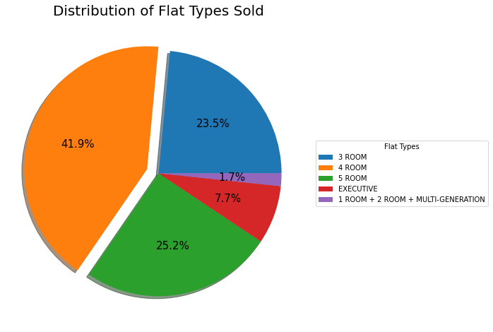

```python
# sum of each flat type
count_1_room = np.sum(data_resale_flat_prices['flat_type']=='1 ROOM')
count_2_room = np.sum(data_resale_flat_prices['flat_type']=='2 ROOM')
count_3_room = np.sum(data_resale_flat_prices['flat_type']=='3 ROOM')
count_4_room = np.sum(data_resale_flat_prices['flat_type']=='4 ROOM')
count_5_room = np.sum(data_resale_flat_prices['flat_type']=='5 ROOM')
count_executive = np.sum(data_resale_flat_prices['flat_type']=='EXECUTIVE')
count_mg = np.sum(data_resale_flat_prices['flat_type']=='MULTI-GENERATION')

# sum of 1 room, 2 room and multi-generation
count_12_and_mg = count_1_room + count_mg +count_2_room

# creating a list of the sum of each flat type
sizes = [count_3_room, count_4_room, count_5_room, count_executive, count_12_and_mg]

# creating a list of the labels
labels = np.unique(data_resale_flat_prices['flat_type'])

# removing 1 room, 2 room and multi-generation from the labels
new_labels = []
for label in labels:
    if label == '1 ROOM':
        np.delete(label, np.where(label == '1 ROOM'))
    elif label == '2 ROOM':
        np.delete(label, np.where(label == '2 ROOM'))
    elif label == 'MULTI-GENERATION':
        continue
    else:
        new_labels.append(label)

# adding a new label for 1 room, 2 room and multi-generation
new_labels.append('1 ROOM + 2 ROOM + MULTI-GENERATION')

explode =(0,0.1,0,0,0)

fig1,ax1 = plt.subplots(figsize=(8,8),facecolor='white')
ax1.pie(sizes,explode=explode,shadow=True, autopct='%1.1f%%',textprops={'fontsize': 15})
plt.legend(new_labels,title="Flat Types",loc="center left" ,bbox_to_anchor=(1, 0.5))
plt.title("Distribution of Flat Types Sold",fontsize=20)
plt.show()
```

The pie chart below shows the breakdown of the number of flats sold in this dataset. There are a total of 7 flat types, but as the 1-room, 2-room and Multi Generation flat types had low numbers of sales, they were combined into one category.

As you can see, the 4-room flat is the most popular type, accounting for over **40%** of all sales. This is likely due to its size and affordability. 4-room flats are typically large enough to accommodate a family of up to four people, while still being relatively affordable. The 5-room flat is the second most popular type, accounting for just over **25%** of all sales. 5-room flats are larger than 4-room flats, and are often chosen by families with more than four children. 3-room flats are the third most popular type, accounting for just over **23%** of all sales. 3-room flats are smaller than 4-room flats, but they are still a popular choice for families with two or three children. Executive flats are the fourth most popular type, accounting for just over **7%** of all sales. Executive flats are larger than 4-room flats, and they often come with additional features such as private lifts and balconies. 1-room, 2-room and Multi Generation flats are the least popular type, accounting for just over **1%** of all sales. These flats are typically chosen by singles, couples or small families who are looking for an affordable option.

I will be choosing the 4-room flat as they have been sold more, which means there is more options of it across different towns. This will give me a wider range of choice when it comes to finding a flat that meets my needs.

### What is the relationship between the lease commence date and the resale prices of 4 room flats?

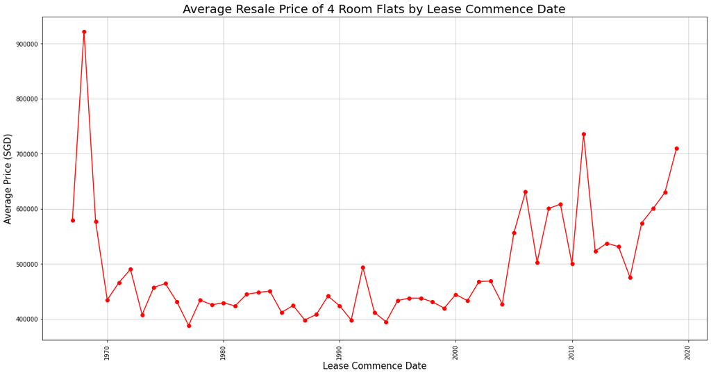

```python
# 4 room flat
room_4 = data_resale_flat_prices[data_resale_flat_prices['flat_type']=='4 ROOM']

lease_commence_date = np.unique(room_4['lease_commence_date'])

# getting the average resale price of each lease commence date
avg_price = []
for date in lease_commence_date:
    avg_price.append(np.mean(room_4[room_4['lease_commence_date']==date]['resale_price']))

plt.figure(figsize=(20,10))
plt.plot(lease_commence_date,avg_price,marker='o',color='red')
plt.title("Average Resale Price of 4 Room Flats by Lease Commence Date",fontsize=20)
plt.xticks(rotation=90)
plt.xlabel('Lease Commence Date',fontsize=15)
plt.ylabel('Average Price (SGD)',fontsize=15)
plt.grid(color="gray",alpha=0.4)
plt.show()
```

This line graph shows the relationship between the lease commence date (LCD) and the average resale price in Singapore dollars (SGD). All HDB flats are leased for a period of 99 years, and the LCD is the starting point for this calculation. A flat with a shorter lease term will be worth less than a flat with a longer lease term.

From the graph, we can see that the average resale price started with a steep increase and then decreased. The average resale price was around 600,000 SGD and it then increased to more than 900000 SGD in a few years. The price dropped back down to 450000 SGD when the LCD was 1970. Flats with an LCD between 1970 and the mid-2000s had average resale prices between 400000 SGD and 500000 SGD.

Flats with an LCD after the mid-2000s saw their average resale price increase. Although there were a few steep drops in prices, the highest it went to was above 700000 SGD. In the mid-2010s, there was a steep increase in price, from 500000 SGD to around 700000 SGD. After that steep drop, there was an increase in the average resale price, around 700000 SGD, as the LCD was closer to 2020.

Even though a flat with a recent LCD would be worth more, there are some older flats with an LCD of before 1970 which had a resale price of above 900000 SGD. There could be several factors affecting this, including the town, flat model, and facilities in that town.

As my budget is 500000 SGD, I will be choosing a 4-room flat with an LCD between 1980 and 2000.

### What is the difference between the flat models in 4 room flats?

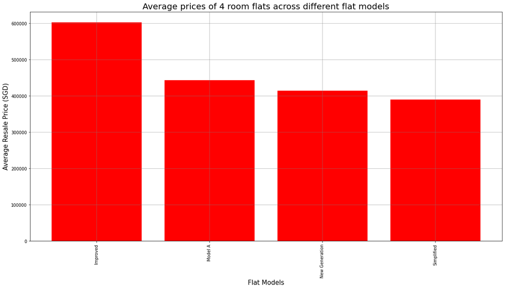

```python
room_4 = data_resale_flat_prices[(data_resale_flat_prices['flat_type'] == '4 ROOM') & (data_resale_flat_prices['lease_commence_date'] >= np.datetime64('1980'))& (data_resale_flat_prices['lease_commence_date'] <= np.datetime64('1990'))]
flat_types = np.unique(room_4['flat_model'])

# getting the average resale price of each flat model
average_price=[]

for flat in flat_types:
    average_price.append(np.mean(room_4[room_4['flat_model']==flat]['resale_price']))

plt.figure(figsize=(20,10))
plt.bar(flat_types,average_price,color='red')
plt.title("Average prices of 4 room flats across different flat models",fontsize=20)
plt.xticks(rotation=90)
plt.xlabel('Flat Models',fontsize=15)
plt.ylabel('Average Resale Price (SGD)',fontsize=15)
plt.grid(color="gray",alpha=0.6)
plt.show()
```

This is a bar chart showing the different flat models and their average resale price. There are four different flat models for 4 room flats, and they are Improved, Model A, New Generation and Simplified.

The most **expensive** flat model is the Improved flat model, which costs 600000SGD. The **cheapest** flat model is Simplified flat model, which costs below 400000SGD.

The average resale prices of flat models are positively correlated with the floor area of the flat model. This means that as the floor area of a flat model increases, so does its average resale price.

I will be choosing the Model A flat model because it is the most cost-effective option.

Info of flat models are from https://www.hdb.gov.sg/ .

### Do flats in higher storeys cost more?

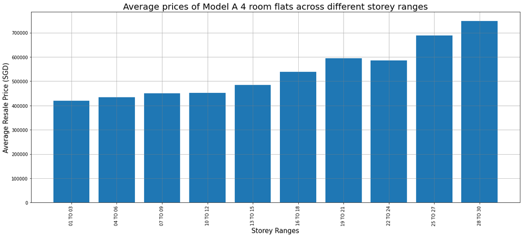

```python
room_4 = data_resale_flat_prices[(data_resale_flat_prices['flat_type'] == '4 ROOM') & (data_resale_flat_prices['lease_commence_date'] >= np.datetime64('1980'))& (data_resale_flat_prices['lease_commence_date'] <= np.datetime64('2000')) & (data_resale_flat_prices['flat_model']=='Model A')]
storey_ranges = np.unique(room_4['storey_range'])

# getting the average resale price of each storey range
average_price_storey = []

for storey in storey_ranges:
    average_price_storey.append(np.mean(room_4[room_4['storey_range']==storey]['resale_price']))

plt.figure(figsize=(20,8))
plt.bar(storey_ranges,average_price_storey)
plt.title("Average prices of Model A 4 room flats across different storey ranges",fontsize=20)
plt.xticks(rotation=90)
plt.xlabel('Storey Ranges',fontsize=15)
plt.ylabel('Average Resale Price (SGD)',fontsize=15)
plt.grid(color="gray",alpha=0.6)
plt.show()
```

This is a bar chart showing the relationship between the storey range and the average resale price of Model A 4 room flats. As the storey range gets higher, the average resale price of the flat increases too. The highest storey range for a Model A 4 room flat is 28 to 30. A flat at this storey range costs more than **700000SGD**. The **cheapest** flat is also the lowest storey range, floors 1 to 3, which costs just above **400000SGD**.

The average resale price of the flats have been increasing as the storey range increased. However, there is an anomaly. The average resale price of a flat on storey range 19 to 21 costs close to 600000SGD. The next storey range,21 to 24 costs around 600000SGD, but it is a bit cheaper than the previous storey range. There might be several factors affecting this.

In conclusion, flats in higher storey ranges do cost more. However, there are some factors that can affect the resale price of a flat, even if it is on a higher storey range. Buyers should carefully consider all of these factors when making a decision about which flat to buy.

Based on the information in the bar chart, I would choose a Model A 4-room flat on storey range 13 to 15. This storey range has an average resale price of around 500000SGD, which is a good value for money. The flats on this storey range are also likely to have good views and plenty of natural light.

### Is there a relationship between the floor area of a property and its resale price?

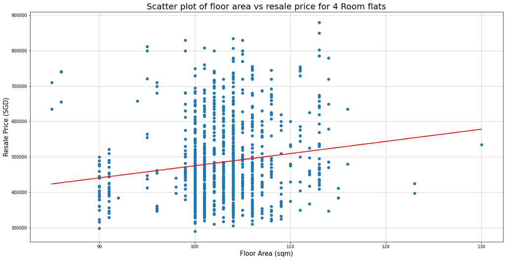

```python
room_4 = data_resale_flat_prices[(data_resale_flat_prices['flat_type'] == '4 ROOM') & (data_resale_flat_prices['lease_commence_date'] >= np.datetime64('1980')) & (
    data_resale_flat_prices['lease_commence_date'] <= np.datetime64('2000')) & (data_resale_flat_prices['flat_model'] == 'Model A') & (data_resale_flat_prices['storey_range'] == '13 TO 15')]

sqm = room_4['floor_area_sqm']
resale_price = room_4['resale_price']

plt.figure(figsize=(20, 10))
a, b = np.polyfit(sqm, resale_price, 1)
plt.scatter(sqm, resale_price)
plt.plot(sqm, a*sqm+b, color='red')
plt.title("Scatter plot of floor area vs resale price for 4 Room flats", fontsize=20)
plt.xlabel('Floor Area (sqm)', fontsize=15)
plt.ylabel('Resale Price (SGD)', fontsize=15)
plt.grid(color="gray", alpha=0.4)
plt.show()
```

The scatter plot shows the relationship between the floor area and resale price of Model A 4-room flats. There is a low positive correlation between the two variables, meaning that as the floor area increases, the resale price also tends to increase. However, there are some outliers, such as the most expensive flat which has a floor area of around 115sqm but costs close to **900000SGD**.

In conclusion, there is a weak positive correlation between the floor area of a flat and its resale price. This means that, on average, flats with larger floor areas tend to sell for more than flats with smaller floor areas. However, there are many other factors that can affect the resale price of a flat, such as its town and facilities.

Given my budget, I will be choosing a flat with a floor area of 100 to 110 sqm. There are plenty of options available in this range.

### Which town in Singapore has Model A 4-room flats with a lease commence date between 1980 and 2000, a floor area between 100 and 110sqm, and a price around 500000 SGD?

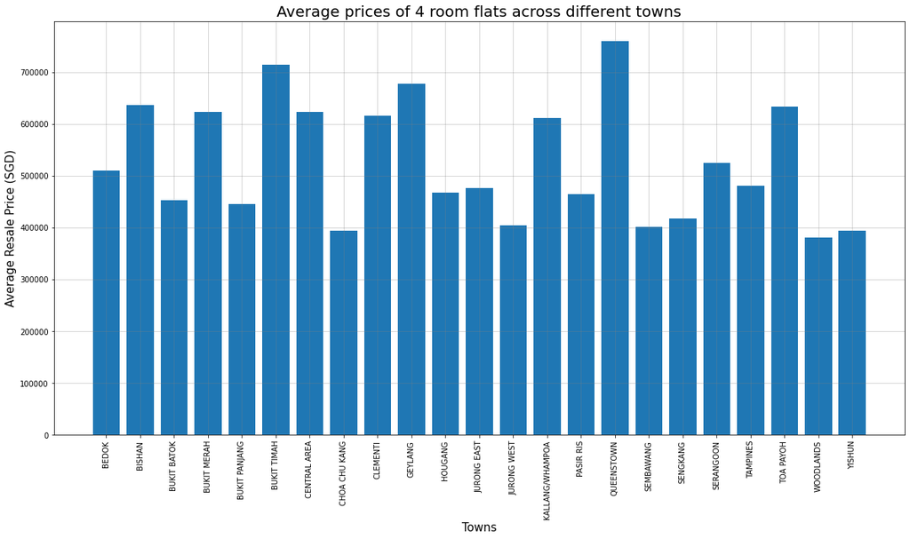

```python
room_4 = data_resale_flat_prices[(data_resale_flat_prices['flat_type'] == '4 ROOM') &
                                 (data_resale_flat_prices['lease_commence_date'] >= np.datetime64('1980')) &
                                 (data_resale_flat_prices['lease_commence_date'] <= np.datetime64('2000')) &
                                 (data_resale_flat_prices['floor_area_sqm'] >= 100) &
                                 (data_resale_flat_prices['floor_area_sqm'] <= 110) &
                                 (data_resale_flat_prices['flat_model'] == 'Model A') &
                                 (data_resale_flat_prices['storey_range'] == '13 TO 15')]

towns = np.unique(room_4['town'])

# getting the average resale price of each town
average_price = []

for town in towns:
    average_price.append(
        np.mean(room_4[room_4['town'] == town]['resale_price']))

plt.figure(figsize=(20, 10))
plt.bar(towns, average_price)
plt.title("Average prices of 4 room flats across different towns", fontsize=20)
plt.xticks(rotation=90)
plt.xlabel('Towns', fontsize=15)
plt.ylabel('Average Resale Price (SGD)', fontsize=15)
plt.grid(color="gray", alpha=0.4)
plt.show()
```

From the bar chart, it is evident that the average resale prices of the same flat models vary across different towns. One possible reason for this disparity is the variation in accessibility to key areas of Singapore, such as the Central Business District (CBD). Higher-costing towns may offer better transportation, educational, and healthcare facilities.

The price gap between the cheapest and most expensive town amounts to approximately **400000 SGD**. Notably, the more expensive towns are situated closer to the center of Singapore, while the less expensive towns are located farther away.

Considering my budget of 500,000 SGD, I have shortlisted the following towns that fall within my price range: Bedok, Serangoon, and Jurong East.

### Insights from the resale flat prices dataset.

This dataset reveals the various factors that impact the resale price of a flat in Singapore. These factors encompass the flat type, flat model, lease commence date, floor area, storey range, and town.

Diverse flat types exhibit varying price points, with higher average resale prices correlating with an increase in the number of rooms and floor area. Prospective buyers are advised to determine their desired flat type by considering the number of bedrooms they require and how they intend to allocate the floor area. Among the available options, the 4-room flats offer an optimal choice as they feature 3 bedrooms and are more affordable compared to other types of flats.

Every flat in Singapore possesses a lease commence date since HDB flats are leased for a period of 99 years. Upon the expiration of this lease, owners are required to return their property to the Housing Development Board (HDB). Consequently, the older the lease commence date, the lower the average resale price tends to be. Buyers who plan to pass on their property ownership to their children are advised to purchase flats with more recent lease commence dates. Conversely, buyers seeking short-term residency (e.g., 10 years) may consider older flats as they are typically more cost-effective.

Within each flat type, there exists a range of flat models. Specifically, for 4-room flats, four distinct models are available: Improved, Model A, New Generation, and Simplified.

Buyers can select a flat model based on their specific requirements and preferred house layout. The Simplified flat model stands as the most affordable option, while the Improved flat model commands the highest price.

Flats situated on higher storeys generally come at a higher cost, given their superior views and increased natural elevation. Buyers who do not prioritize this aspect have the option of acquiring a flat on a lower storey, which would be more economical. However, those seeking enhanced views may opt to purchase a flat on a higher storey, albeit at a higher price point.

The selection of a town holds significant importance when purchasing a flat, with certain towns offering greater accessibility to the airport, Central Business District (CBD), educational institutions, and healthcare facilities. Buyers seeking to minimize travel time may consider acquiring a flat in prime areas such as Queenstown and Bukit Timah, with prices ranging from 700,000 to 800,000 SGD. Alternatively, those willing to trade off travel time for affordability can explore flats in Choa Chu Kang, Jurong West, Sembawang, Woodlands, and Yishun, which are priced at approximately 400,000 SGD.

This dataset demonstrates the abundance of options available for prospective buyers, thereby facilitating their decision-making process when selecting a flat that fulfills their requirements.

## Median rent by town and flat type dataset

### How much do median rental prices vary in Serangoon, Bedok, and Jurong East?

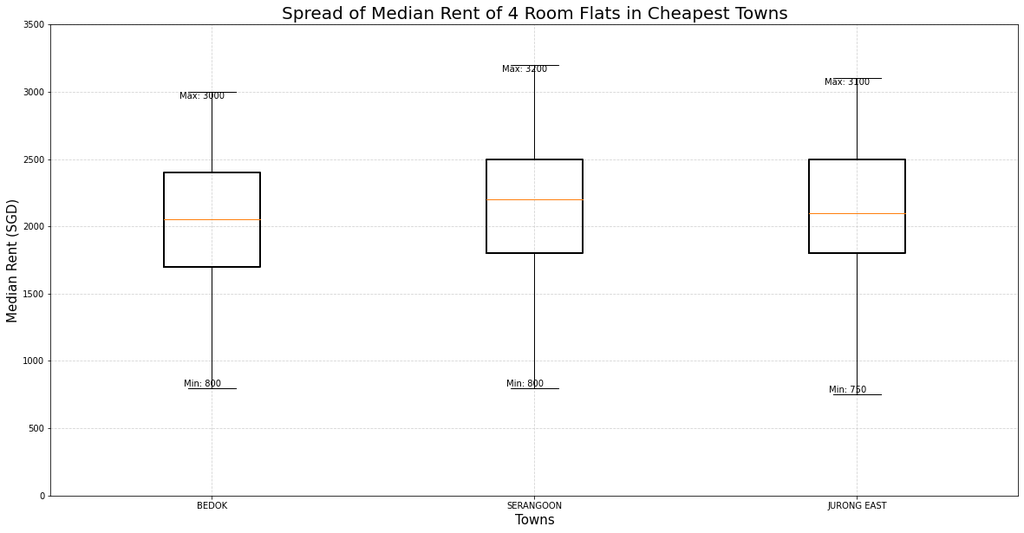

```python
data_median_rent['town'] = np.char.strip(data_median_rent['town'])

towns=["BEDOK","SERANGOON","JURONG EAST"]

cheapest_towns=[]

for town in towns:
    cheapest_towns.append(np.unique(data_median_rent[data_median_rent['town']==town]['town']))

#chatgpt Extract the town names from the numpy arrays
cheapest_towns = [town[0] for town in cheapest_towns]

median_rent_of_town = []

for town in cheapest_towns:
    median_rent_of_town.append(data_median_rent[data_median_rent['town']==town]['median_rent'])

#chatgpt Remove the -1 values from the arrays
median_rent_of_town = [rent[rent != -1] for rent in median_rent_of_town]

# creating boxplot

#setting figure size
plt.figure(figsize=(20, 10))

#make lines of boxplot thicker
boxprops = dict(linewidth=2)

#plotting the boxplot
bp = plt.boxplot(median_rent_of_town, labels=cheapest_towns, boxprops=boxprops)

#title, xlables, ylabels, and grid
plt.title("Spread of Median Rent of 4 Room Flats in Cheapest Towns", fontsize=20)
plt.xlabel('Towns', fontsize=15)
plt.ylabel('Median Rent (SGD)', fontsize=15)
plt.ylim(0, 3500)
plt.grid(color="lightgray", linestyle='--')

# Add labels for minimum and maximum values
#loops through each box in the boxplot
for i, box in enumerate(bp['boxes']):

    # Get the coordinates of the box and whiskers
    #x coordinates
    x = box.get_xdata()
    #y coordinates
    y = box.get_ydata()

    # gets whiskers
    whiskers = bp['whiskers']

    # to get the x coordinates for each whisker
    whisker_x = [whiskers[i*2].get_xdata()[1], whiskers[i*2 + 1].get_xdata()[1]]

    # gets y coordinates for the whisker at the bottom
    whisker_y_min = whiskers[i*2].get_ydata()[1]

    # gets y coordinates for the whisker at the top
    whisker_y_max = whiskers[i*2 + 1].get_ydata()[1]

    # to position labels
    label_x = x.mean()
    label_y_min = whisker_y_min
    label_y_max = whisker_y_max

    # Add the labels
    plt.text(label_x, label_y_min, f'Min: {label_y_min:.0f}', ha='center', va='bottom')
    plt.text(label_x, label_y_max, f'Max: {label_y_max:.0f}', ha='center', va='top')

plt.show()
```

The minimum median rental price in Bedok is 800SGD, while the maximum is 3000SGD. The minimum median rental price in Serangoon is 800SGD, while the maximum is 3200SGD. The minimum median rental price in Jurong East is 750SGD, while the maximum is 3100SGD. The difference between the minimum and maximum median rental price for each of these towns is 2200SGD, 2400SGD and 2350SGD respectively.

It is important to consider additional factors such as facilities when looking at median rent values.

I will be choosing Serangoon as the town I want to buy a flat in, as the maximum median rental price is the highest, at 3200SGD.

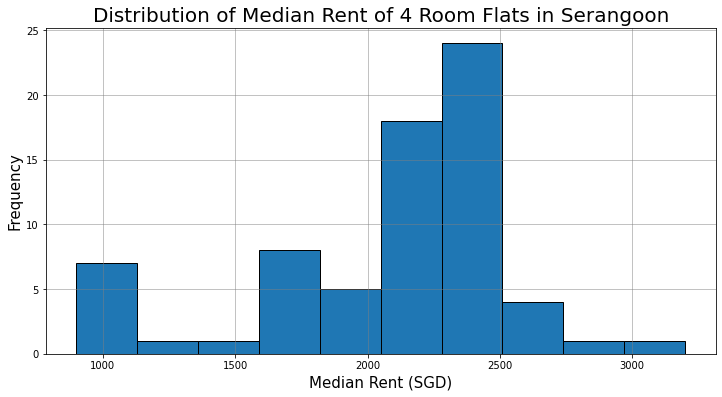

```python
median_rent = data_median_rent[(data_median_rent['flat_type']=='4-RM') & (data_median_rent['town']=='SERANGOON')]['median_rent']

# removing -1 values
for rent in median_rent:
    if rent == -1:
        median_rent = np.delete(median_rent, np.where(median_rent == -1))

plt.figure(figsize=(12, 6))
plt.hist(median_rent, bins=10, edgecolor="black")
plt.xlabel('Median Rent (SGD)',fontsize=15)
plt.ylabel('Frequency',fontsize=15)
plt.title('Distribution of Median Rent of 4 Room Flats in Serangoon',fontsize=20)
plt.grid(color="gray",alpha=0.6)
plt.show()
```

Considering the central tendency of the data, with a significant number of flats being rented out at approximately 2500 SGD, it would be reasonable to set the rental price for my 4-room flat in line with this prevailing rate.

### What is the trend between quarters and the median rental price?

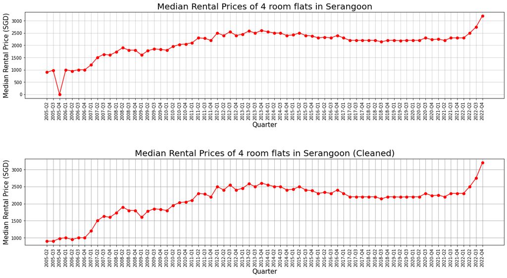

```python
# Extracting data for Serangoon and 4 Room
room_4 = data_median_rent[(data_median_rent['town']=='SERANGOON') & (data_median_rent['flat_type']=='4-RM')]

# getting the different quarters
quarters = np.unique(room_4['quarter'])

median_rental_price = []

#finding the median rental price for each quarter
for quarter in quarters:
    median_rental_price.extend(room_4[room_4['quarter']==quarter]['median_rent'])

median_rental_price = np.array(median_rental_price)

median_rental_price = median_rental_price[1:]

#plotting the graph
plt.figure(1)
plt.figure(figsize=(20,10))
plt.subplot(211)
plt.plot(quarters,median_rental_price,marker='o',color='red')
plt.title("Median Rental Prices of 4 room flats in Serangoon",fontsize=20)
plt.xticks(rotation=90)
plt.xlabel('Quarter',fontsize=15)
plt.ylabel('Median Rental Price (SGD)',fontsize=15)
plt.grid(color="gray",alpha=0.4)

data_median_rent['town'] = np.char.strip(data_median_rent['town'])

room_4 = data_median_rent[(data_median_rent['flat_type'] == '4-RM') & (data_median_rent['town'] == 'SERANGOON')]

quarters = np.unique(room_4['quarter'])

median_rent_cleaned = []

for quarter in quarters:
    median_rent_cleaned.extend(room_4[room_4['quarter']==quarter]['median_rent'])

for rent in median_rent_cleaned:
    median_rent_cleaned = np.delete(median_rent_cleaned, np.where(median_rent_cleaned == -1))

plt.subplot(212)
plt.plot(quarters,median_rent_cleaned,marker='o',color='red')
plt.title("Median Rental Prices of 4 room flats in Serangoon (Cleaned)",fontsize=20)
plt.xticks(rotation=90)
plt.xlabel('Quarter',fontsize=15)
plt.ylabel('Median Rental Price (SGD)',fontsize=15)
plt.grid(color="gray",alpha=0.7)
plt.subplots_adjust(hspace=0.7)  # chatgpt Adjust the value as per your desired spacing

plt.show()
```

This figure illustrates the trend between quarters in different years and the median rental price for 4-room flats in Serangoon. It consists of two line graphs: the top graph displays the uncleaned data, while the bottom graph showcases the accurate data.

Examining the first line graph, we observe an inconsistency in the dataset. In 2005-Q3, the median rental price is depicted as 1000 SGD, but it abruptly drops to 0 SGD in the subsequent quarter, indicating an error. Consequently, the dataset underwent a simple cleaning process to ensure the accuracy of the data analysis.

The second line graph provides a more reliable representation. It demonstrates the trend between quarters within a year and the corresponding median rental price. Over the years, there is a consistent increase in the median rental price. From 2005-Q2 to 2006-Q4, the median rental price remained relatively stable at around 1000 SGD. Subsequently, it climbed to approximately 2000 SGD in 2008-Q2. Gradually, the median rental price continued its ascent, surpassing 2500 SGD in 2012-Q3, where it plateaued until 2015-Q2. Following that, it experienced a slight decline, hovering around 2250 SGD until 2022-Q2. Subsequently, in 2022-Q4, there was a sharp surge, propelling the median rental price above 3000 SGD.

The primary factor contributing to the upward trajectory of the median rental price over time is the availability of educational and healthcare facilities in the vicinity. As these facilities expand, they enhance accessibility, thereby increasing the median rental price for flats in the area.

Considering the current trend of increasing median rental prices, opting to rent a 4-room flat in Serangoon appears to be a good decision.

### Insights on the median rent by town and flat type dataset.

Within our dataset, we placed our primary focus on three towns that align with our budgetary considerations: Bedok, Serangoon, and Jurong East.

Furthermore, we explored the temporal aspect by analyzing the relationship between quarters in different years and the corresponding median rental prices. Over time, there was a discernible upward trend in the median rental price of 4-room flats in Serangoon. Notably, a significant surge occurred after the first quarter of 2022, where the median rental price experienced a substantial leap from 2250SGD to approximately 3000SGD.

For owners of 4-room flats in Serangoon who are considering renting out their properties, the present moment presents an opportune time. The increasing median rental prices indicate a favorable market condition that can yield a substantial profit for property owners.

## Renting out of flats dataset

### How do the average rental prices of 4 room flats vary across different streets in Serangoon?

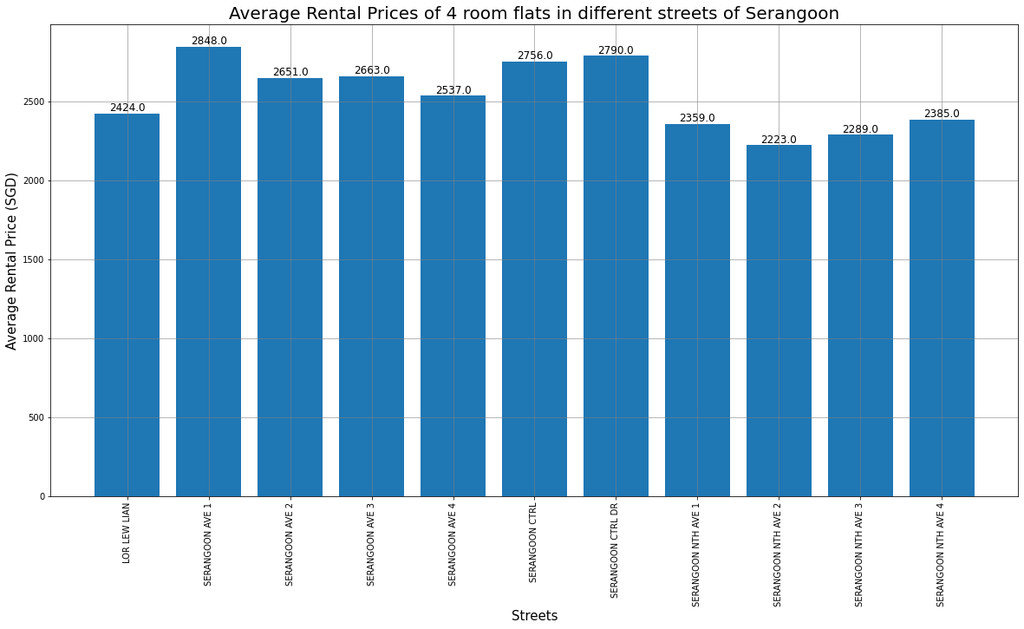

```python
streets_in_sr = np.unique(data_renting_flats[(data_renting_flats['flat_type']=='4-ROOM') & (data_renting_flats['town']=='SERANGOON')]['street_name'])

# getting the average rental price of each street
average_rental_price = []

for streets in streets_in_sr:
    average_rental_price.append(np.mean(data_renting_flats[(data_renting_flats['flat_type']=='4-ROOM') & (data_renting_flats['town']=='SERANGOON') & (data_renting_flats['street_name']==streets)]['monthly_rent']))

plt.figure(figsize=(20,10))
plt.bar(streets_in_sr,average_rental_price)
plt.title("Average Rental Prices of 4 room flats in different streets of Serangoon",fontsize=20)
plt.xticks(rotation=90)
plt.xlabel('Streets',fontsize=15)
plt.ylabel('Average Rental Price (SGD)',fontsize=15)
plt.grid(color="gray",alpha=0.7)

for i, price in enumerate(average_rental_price):
    plt.text(i, price, str(round(price, 0)), ha='center', va='bottom', fontsize=12)

plt.show()
```

This bar chart illustrates the average rental prices of 4-room flats in different streets of Serangoon. It provides valuable insights into the variation of rental prices across these streets, allowing potential renters to make informed decisions.

Among the 11 streets in Serangoon, Serangoon Ave 1 stands out with the highest average rental price of 2848 SGD. Following closely is Serangoon Central Drive (Serangoon CTRL DR) with an average rental price of 2790 SGD. Conversely, Serangoon North Avenue 2 (Serangoon NTH AVE 2) offers the most affordable option, with an average rental price of 2223 SGD. Notably, there is a significant difference of 625 SGD in average rental prices among these streets.

The variation in average rental prices can be attributed to factors such as proximity to transportation networks and other essential facilities. Streets that are located closer to these amenities tend to command higher rental prices, as they offer the convenience of shorter travel times.

Renters should carefully consider their preferences and requirements when choosing a street. Those seeking proximity to facilities may opt to pay a higher cost for a street like Serangoon Ave 1 or Serangoon Central Drive. On the other hand, individuals prioritizing affordability can explore the option of renting a flat in Serangoon North Avenue 2, given its comparatively lower average rental price.

I have decided to select a 4-room flat in Serangoon Avenue 1, taking into account the higher rental price. This choice is driven by the potential for greater profitability in the rental market.

### What is the optimal timing for renting out a 4-room flat in Serangoon?

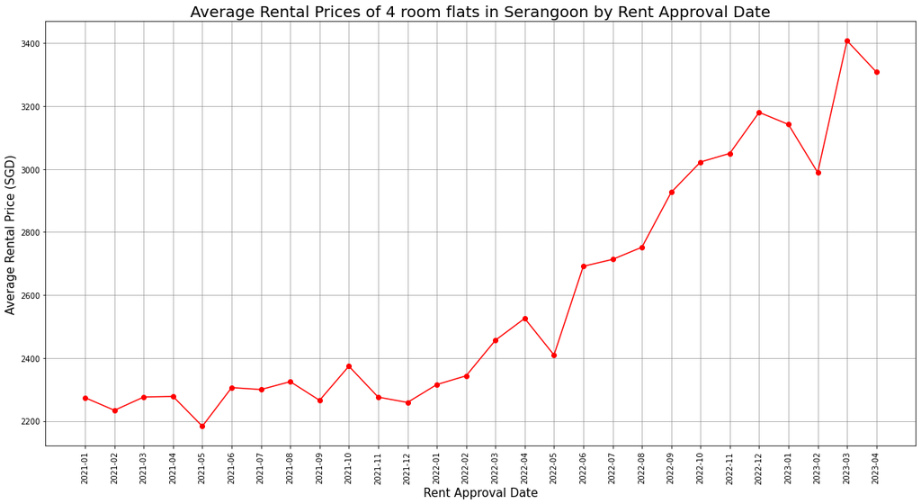

```python
serangoon_rental = data_renting_flats[(data_renting_flats['flat_type'] == '4-ROOM') & (data_renting_flats['town'] == 'SERANGOON')]

rental_approval_date = np.unique(serangoon_rental['rent_approval_date'])

avg_rent = []
for rent in rental_approval_date:
    avg_rent.append(np.mean(serangoon_rental[serangoon_rental['rent_approval_date']==rent]['monthly_rent']))

plt.figure(figsize=(20,10))
plt.plot(rental_approval_date,avg_rent,marker='o',color='red')
plt.title("Average Rental Prices of 4 room flats in Serangoon by Rent Approval Date",fontsize=20)
plt.xticks(rotation=90)
plt.xlabel('Rent Approval Date',fontsize=15)
plt.ylabel('Average Rental Price (SGD)',fontsize=15)
plt.grid(color="gray",alpha=0.7)
plt.show()
```

This line graph illustrates the correlation between the approval date of rent and the average rental price for 4-room flats in Serangoon. It clearly demonstrates that as the rent approval date becomes more recent, there is a noticeable upward trend in the average rental price.

For homeowners in Serangoon considering renting out their flats, the present time presents the highest potential for profitability as the average rental price has reached its peak. This period is the most advantageous for renting out their property. Conversely, individuals seeking to rent in Serangoon may benefit from waiting a bit longer, as the line graph indicates a decreasing trend in prices. However, it is important to note that this downward movement in rental prices was observed for only a month, and future trends remain uncertain.

### Insights from the renting out of flats dataset.

The primary focus of this dataset revolves around the town of Serangoon and specifically targets 4-room flats.

To visually represent the average rental prices across different streets in Serangoon, we employed a bar chart. This chart provides prospective renters with a diverse range of options to consider, depending on their individual requirements. Notably, the rental prices tend to be higher for flats located in close proximity to transportation facilities, while more affordable options can be found in areas further away from these conveniences.

Additionally, we utilized a line graph to determine the optimal time for renting out a flat. Fortunately, the average rental price for 4-room flats in Serangoon has recently peaked, indicating that the present moment presents an excellent opportunity for renting out a property. For those intending to rent, it is advisable to exercise some patience, as prices may potentially undergo a downward trend.

Considering my own intention to purchase a flat, I would personally opt for a property situated on Serangoon Avenue 1. This particular street boasts a high average rental price, making it an attractive choice for investment. Given the current rental market conditions, it would be prudent to promptly rent out the acquired property, as the average rental price remains near its peak at 3400 SGD.

## General information of schools dataset

### What is the number of schools in various towns across Singapore?

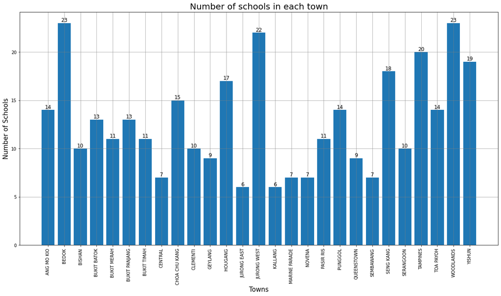

```python
towns = np.unique(data_school_info['dgp_code'])

num_schools=[]

for town in towns:
    num_schools.append(np.sum(data_school_info['dgp_code']==town))

plt.figure(figsize=(20,10))
plt.bar(towns,num_schools)
plt.title("Number of schools in each town",fontsize=20)
plt.xticks(rotation=90)
plt.xlabel('Towns',fontsize=15)
plt.ylabel('Number of Schools',fontsize=15)
plt.grid(color="gray",alpha=0.7)

for i, amt in enumerate(num_schools):
    plt.text(i, amt, str(round(amt, 0)), ha='center', va='bottom', fontsize=12)


plt.show()
```

This bar chart illustrates the distribution of schools across different towns in Singapore.

Bedok and Woodlands stand out as the towns with the highest number of schools, with a total of 23 schools each. Following closely behind is Jurong West with 22 schools. On the other hand, Kallang and Jurong East have the lowest number of schools among the towns, with only 6 schools. Interestingly, despite being the most expensive town, Queenstown has a relatively smaller number of schools, with a count of 9. Meanwhile, Serangoon offers a respectable number of schools, with a total of 10.

For prospective buyers seeking a wide range of educational options within their chosen town, both Bedok and Woodlands present attractive choices, as they offer ample school options while being relatively affordable.

### How many different type of schools are in Serangoon, and what are they?

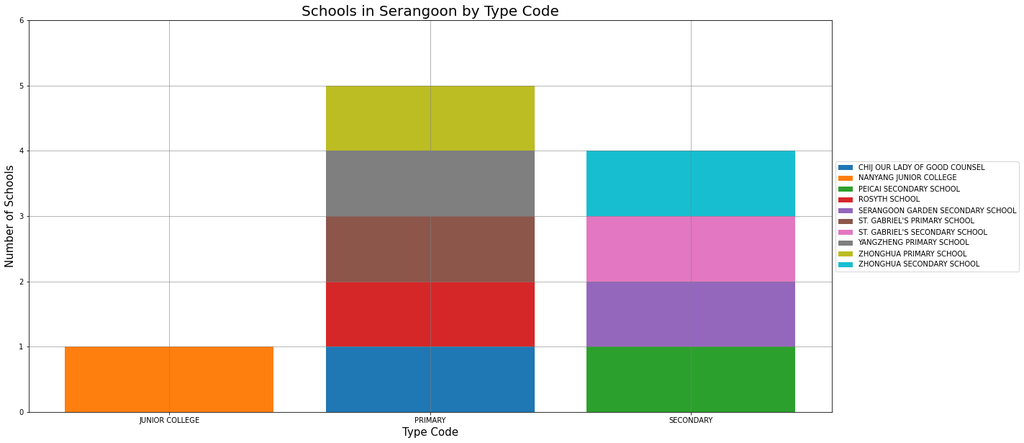

```python
# Extract the schools in serangoon area
serangoon = data_school_info[data_school_info['dgp_code'] == 'SERANGOON']

#get school names
school_names = np.unique(serangoon['school_name'])

# get the main level code for each school (primary,secondary,jc)
main_level= np.unique(serangoon['mainlevel_code'])

# get the number of schools for each main level code
num_schools = []
for main in main_level:
    num_schools.append(len(serangoon[serangoon['mainlevel_code'] == main]))

# Create the stacked bar chart
plt.figure(figsize=(20, 10))

# used to track the bottom position of each bar
bottom = np.zeros(len(main_level))

# loop each school name
for school_name in school_names:

    # filter dataset for current sch
    school_data = serangoon[serangoon['school_name'] == school_name]
    # store the counts for school type
    counts = []
    for code in main_level:
        # filter dataset for current type code and get its count
        count = len(school_data[school_data['mainlevel_code'] == code])
        counts.append(count)
    plt.bar(main_level, counts, bottom=bottom, label=school_name)
    bottom += counts

plt.xlabel('Type Code',fontsize=15)
plt.ylabel('Number of Schools',fontsize=15)
plt.ylim(0,6)
plt.title('Schools in Serangoon by Type Code',fontsize=20)
plt.grid(color="gray",alpha=0.7)
plt.legend(loc='center left', bbox_to_anchor=(1, 0.5))
plt.show()
```

This is an informative bar chart depicting the distribution of schools in Serangoon based on their types, namely Junior College, Primary School, and Secondary School. The Serangoon area hosts a total of three types of schools.

Specifically, Nanyang Junior College represents the sole Junior College in Serangoon. As for Primary Schools, there are five options available: CHIJ Our Lady of Good Counsel, Rosyth School, St. Gabriel's Primary School, Yangzheng Primary School, and Zhonghua Primary School. Additionally, Serangoon is home to four Secondary Schools, namely Peicai Secondary School, Serangoon Garden Secondary School, St. Gabriel's Secondary School, and Zhonghua Secondary School.

Although Serangoon may not boast the highest or lowest property prices in Singapore, this insightful bar chart showcases the abundance of educational institutions available within the area. Therefore, prospective property buyers with children are encouraged to consider Serangoon as an ideal location, offering a diverse range of school options.

### Insights of general information of schools dataset.

This dataset was utilized to analyze the number of schools in different towns across Singapore.

Contrary to expectations, the data reveals that the presence of more schools in a particular town does not necessarily correspond to higher housing prices. For instance, Woodlands boasts the highest number of schools among the towns, yet it is considered one of the more affordable areas. Conversely, Queenstown, with approximately 9 schools, commands higher property costs.

Based on the findings of this dataset, Serangoon emerges as an appealing choice for homebuyers with school-going children. The town offers a diverse selection of educational institutions, including 1 Junior College, 5 Primary Schools, and 4 Secondary Schools. Considering the abundance of educational facilities, the average rental prices of 4 room flats in Serangoon remain reasonably priced.

Prospective buyers are advised to carefully consider the number of schools available in their desired location, taking into account their specific needs and preferences.

## Conclusion of this Data Analysis

The data analysis concludes here, shedding light on several key factors that influence the resale price of a flat. These factors encompass the type and model of the flat, storey range, lease commencement date, floor area, and the presence of educational facilities. It is important to note that there may be additional factors that have not yet been explored.